# HW 02

Author

Sravani Maddineni

## 1 - A new day, a new plot, a new geom

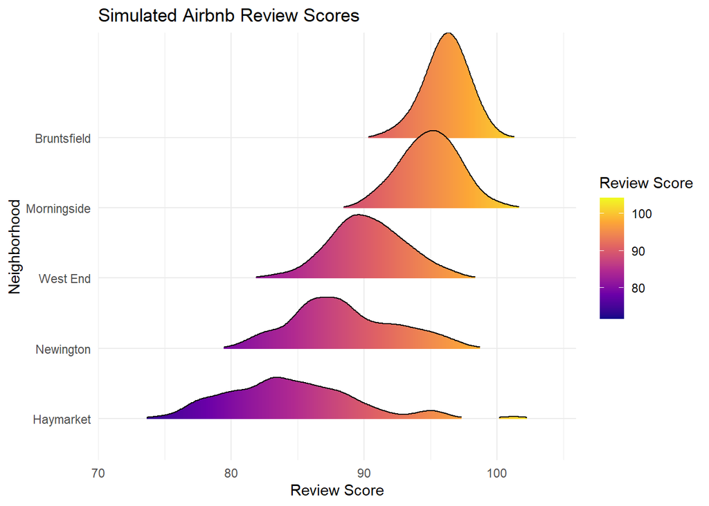

```r
library(ggplot2)
library(ggridges)

# Simulated data
set.seed(123)
edibnb <- data.frame(
  neighbourhood = rep(c("West End", "Haymarket", "Newington", "Morningside", "Bruntsfield"), each = 100),
  review_scores_rating = c(
    rnorm(100, 90, 3),
    rnorm(100, 85, 5),
    rnorm(100, 88, 4),
    rnorm(100, 95, 2),
    rnorm(100, 96, 1.5)
  )
)

# Reorder and plot
edibnb$neighbourhood <- reorder(edibnb$neighbourhood, edibnb$review_scores_rating, median, na.rm = TRUE)

ggplot(edibnb, aes(x = review_scores_rating, y = neighbourhood, fill = after_stat(x))) +
  geom_density_ridges_gradient(scale = 1.5, rel_min_height = 0.01) +
  scale_fill_viridis_c(name = "Review Score", option = "C") +
  labs(title = "Simulated Airbnb Review Scores", x = "Review Score", y = "Neighborhood") +
  theme_minimal()
```

Interpretion:

The ridge plot displays the distribution of simulated Airbnb review scores across five Edinburgh neighborhoods. Each ridge represents the spread and density of review scores for a neighborhood, with neighborhoods sorted by their **median ratings**.

From the plot:

- **Bruntsfield** and **Morningside** show the highest concentration of scores near the top end (above 95), indicating consistently high guest satisfaction.
- **West End** and **Newington** also have relatively high scores but with broader distributions, suggesting more variation in guest experiences.
- **Haymarket** has the widest spread and the lowest median, showing more variability and slightly lower average ratings.
- The **color gradient** enhances the plot by showing intensity tied to the score values, making it easier to compare neighborhoods visually. Overall, the plot suggests that Bruntsfield and Morningside offer the most reliably high-rated Airbnb experiences in this simulated data.

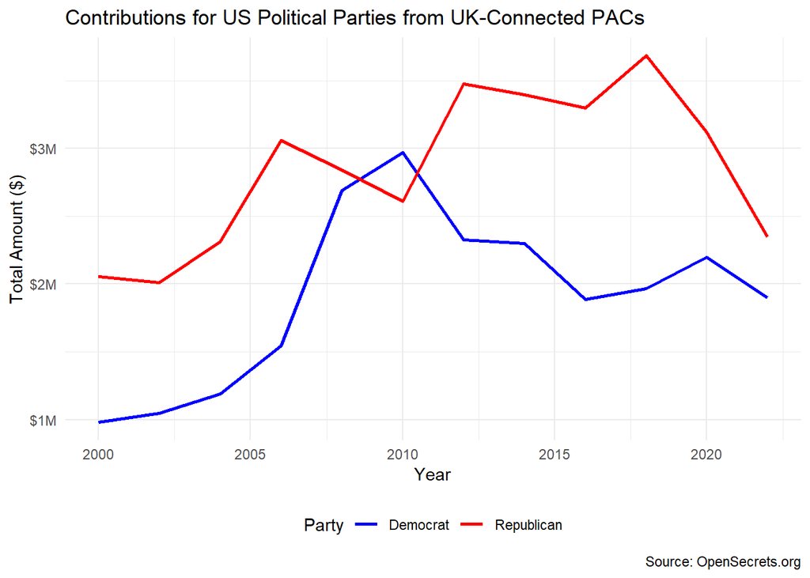

```r
## 2 - Foreign Connected PACs

## 2 - Foreign Connected PACs

library(ggridges)
library(dplyr)
library(ggplot2)
library(readr)
library(tidyr)
library(janitor)
library(fs)
library(purrr)
library(stringr)

list_of_files <- dir_ls(path = "data", regexp = "Foreign Connected PAC")

pac <- list_of_files %>%
  map_dfr(~ {
    year <- str_extract(.x, "\\d{4}-\\d{4}") %>% str_extract("\\d{4}$")
    read_csv(.x, show_col_types = FALSE) %>%
      mutate(year = as.integer(year))
  }) %>%
  clean_names()

pac_long <- pac %>%
  mutate(across(c(total, dems, repubs), ~ as.numeric(gsub("[^0-9.]", "", .)))) %>%
  pivot_longer(cols = c(dems, repubs), names_to = "party", values_to = "amount")

uk_contributions <- pac_long %>%
  mutate(country_of_origin = sub("/.*", "", country_of_origin_parent_company)) %>%
  filter(country_of_origin == "UK") %>%
  group_by(year, party) %>%
  summarize(total_amount = sum(amount, na.rm = TRUE), .groups = 'drop') %>%
  mutate(party = recode(party, dems = "Democrat", repubs = "Republican"))

ggplot(uk_contributions, aes(x = year, y = total_amount, color = party, group = party)) +
  geom_line(linewidth = 1) +
  labs(
    title = "Contributions for US Political Parties from UK-Connected PACs",
    x = "Year", y = "Total Amount ($)", color = "Party",
    caption = "Source: OpenSecrets.org"
  ) +
  theme_minimal() +
  scale_y_continuous(labels = scales::label_dollar(scale_cut = scales::cut_short_scale())) +
  scale_color_manual(values = c("Democrat" = "blue", "Republican" = "red")) +
  theme(legend.position = "bottom")
```

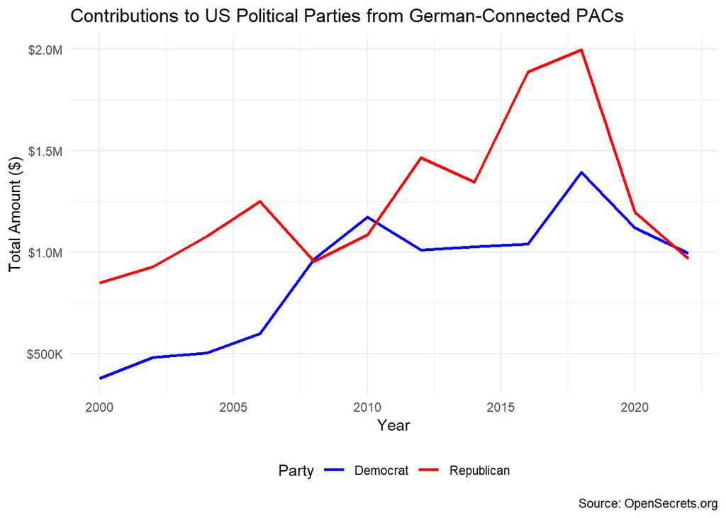

```r
# Germany Plot
germany_contributions <- pac_long %>%
  mutate(country_of_origin = sub("/.*", "", country_of_origin_parent_company)) %>%
  filter(country_of_origin == "Germany") %>%
  group_by(year, party) %>%
  summarize(total_amount = sum(amount, na.rm = TRUE), .groups = 'drop') %>%
  mutate(party = recode(party, dems = "Democrat", repubs = "Republican"))

ggplot(germany_contributions, aes(x = year, y = total_amount, color = party, group = party)) +
  geom_line(linewidth = 1) +
  labs(
    title = "Contributions to US Political Parties from German-Connected PACs",
    x = "Year", y = "Total Amount ($)", color = "Party",
    caption = "Source: OpenSecrets.org"
  ) +
  theme_minimal() +
  scale_y_continuous(labels = scales::label_dollar(scale_cut = scales::cut_short_scale())) +
  scale_color_manual(values = c("Democrat" = "blue", "Republican" = "red")) +
  theme(legend.position = "bottom")
```

Interpretion:

The data shows that German-connected PACs have historically favored Republican candidates, with a significant funding gap observed in 2018—$1,997,550 to Republicans versus $1,394,075 to Democrats. Although Republicans continued to receive more in 2020, the gap narrowed. By 2022, contributions from German-connected PACs nearly equalized, with Democrats slightly surpassing Republicans ($993,800 vs. $969,500). This progression suggests a shift toward more balanced political support, indicating that German interests may be diversifying their affiliations within U.S. politics and engaging more evenly with both major parties.

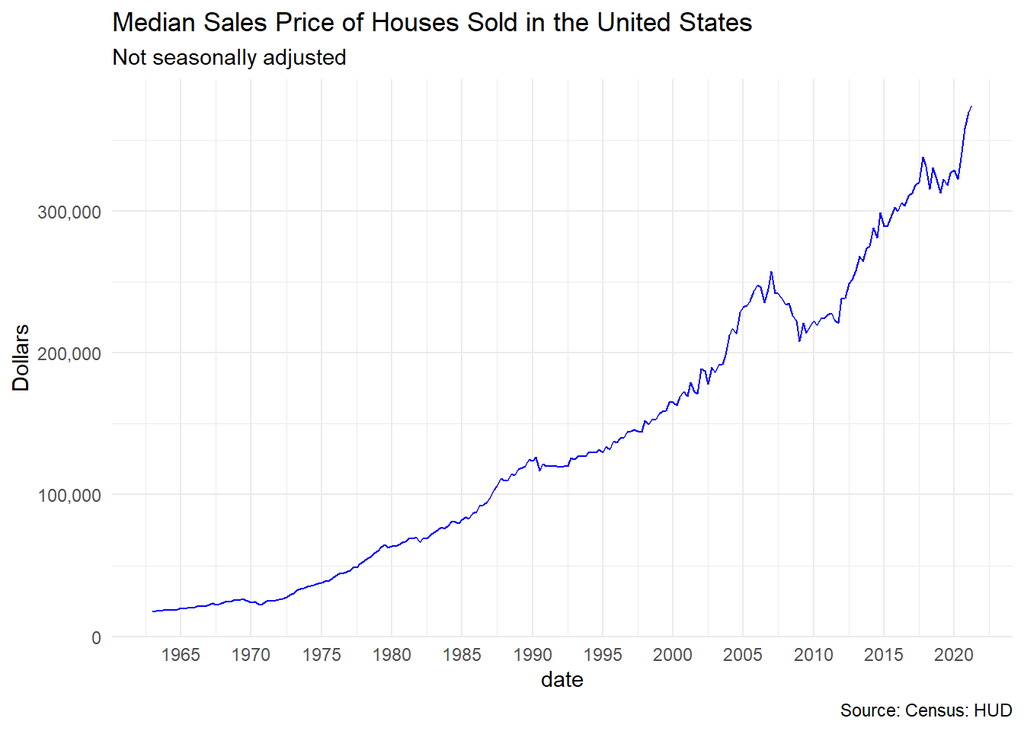

```r
## 3 - Median housing prices in the Us

library(tidyverse)
library(scales)
library(lubridate)

median_housing <- read_csv("data/median-housing.csv") %>%
  rename(date = DATE, price = MSPUS)
recessions <- read_csv("data/recessions.csv") %>%
  rename(peak = Peak, trough = Trough)


ggplot(median_housing, aes(x = date, y = price)) +
  geom_line(color = "blue") +
  labs(
    title = "Median Sales Price of Houses Sold in the United States",
    subtitle = "Not seasonally adjusted",
    y = "Dollars",
    caption = "Source: Census: HUD"
  ) +
  scale_y_continuous(labels = comma) +
  scale_x_date(date_breaks = "5 years", date_labels = "%Y") +
  theme_minimal()
```

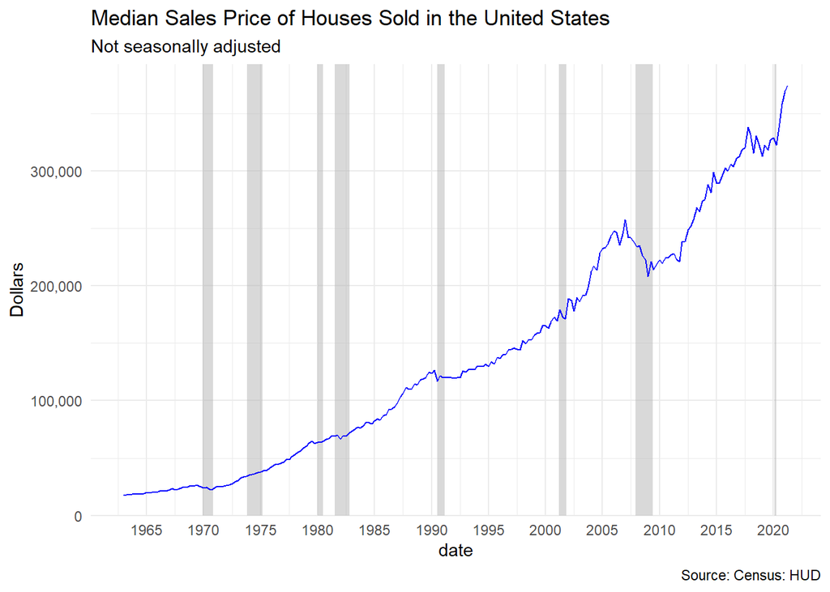

```r
start_date <- min(median_housing$date)
end_date <- max(median_housing$date)

recessions <- recessions %>%
  mutate(during_period = (peak <= end_date & trough >= start_date))

ggplot() +
  geom_rect(data = filter(recessions, during_period),
            aes(xmin = peak, xmax = trough, ymin = -Inf, ymax = Inf),
            fill = "gray70", alpha = 0.5) +
  geom_line(data = median_housing, aes(x = date, y = price), color = "blue") +
  labs(
    title = "Median Sales Price of Houses Sold in the United States",
    subtitle = "Not seasonally adjusted",
    y = "Dollars",
    caption = "Source: Census: HUD"
  ) +
  scale_y_continuous(labels = comma) +
  scale_x_date(date_breaks = "5 years", date_labels = "%Y") +
  theme_minimal()
```

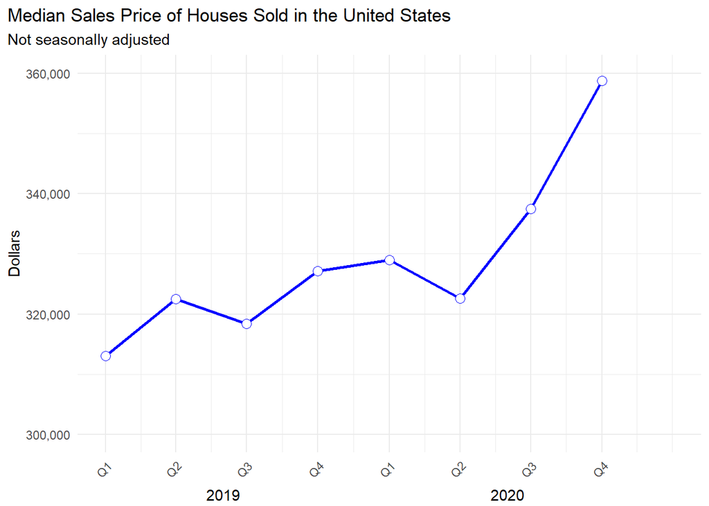

```r
# Create a dataset for 2019 and 2020 only
median_housing_subset <- median_housing %>%
  filter(lubridate::year(date) %in% c(2019, 2020)) %>%
  mutate(
    year = lubridate::year(date),
    quarter = case_when(
      lubridate::month(date) %in% 1:3 ~ "Q1",
      lubridate::month(date) %in% 4:6 ~ "Q2",
      lubridate::month(date) %in% 7:9 ~ "Q3",
      TRUE ~ "Q4"
    )
  )



# Create the plot with adjusted color and other improvements
median_housing_subset %>%
mutate(year_quarter = factor(paste(year, "|", quarter))) %>%
ggplot(aes(x = date, y = price)) +
geom_line(colour = "blue", size = 1) + # Change line color to dark green
geom_point(colour = "blue", fill = "white", shape = 21, size = 3) + # Adjust point color and size
scale_y_continuous(
  name = "Dollars",
  breaks = seq(300000, 360000, by = 20000),
  labels = scales::comma
) +

scale_x_date(name = "", # Remove x-axis name
breaks = median_housing_subset$date,
labels = median_housing_subset$quarter) + # Display quarters on x-axis
labs(title = "Median Sales Price of Houses Sold in the United States",
subtitle = "Not seasonally adjusted",
x = NULL) +
coord_cartesian(clip = "off", ylim = c(300000, 360000),
xlim = c(as.Date("2019-01-01"), as.Date("2020-12-31"))) +
annotate("text", x = as.Date("2019-06-01"), y = 290000, label = "2019") +
annotate("text", x = as.Date("2020-06-01"), y = 290000, label = "2020") +
theme_minimal() +
theme(plot.title.position = "plot",
axis.text.x = element_text(angle = 45, hjust = 1)) # Rotate x-axis labels for clarity
```

[figure not shown]

```r
## 4 - Expect More. plot More.

library(ggplot2)
library(tibble)

# Create concentric circles as data
data <- tibble(
  x = rep(0, 3),
  y = rep(0, 3),
  size = c(30, 20, 10),  # circle sizes (outer to inner)
  color = c("red", "white", "red")  # fill colors
)

ggplot() +
  geom_point(
    data = data,
    aes(x = x, y = y, size = size, color = color),
    shape = 21,
    fill = data$color,
    stroke = 0
  ) +
  scale_size_identity() +
  scale_color_identity() +
  theme_void() +
  coord_fixed() +
  xlim(-35, 35) +
  ylim(-55, 55) +
  annotate("text", x = -3, y = -35, label = "TARGET", size = 8, color = "red", fontface = "bold") +
  annotate("text", x = 16, y = -38, label = "®", size = 6, color = "red")  # Registered trademark symbol
```

Interpretion:

This code creates a simple version of the Target store logo using R’s `ggplot2` package. It draws three concentric circles centered at the same point, with sizes and colors arranged as red (outer), white (middle), and red (inner) to mimic the Target symbol. The `geom_point()` function is used to plot these circles, and `theme_void()` removes all axes and backgrounds to keep the focus on the shapes. The `coord_fixed()` function ensures the circles stay perfectly round. Additionally, the plot adds bold red text that says “TARGET” and a small red “®” to simulate the registered trademark, completing the logo-like appearance.

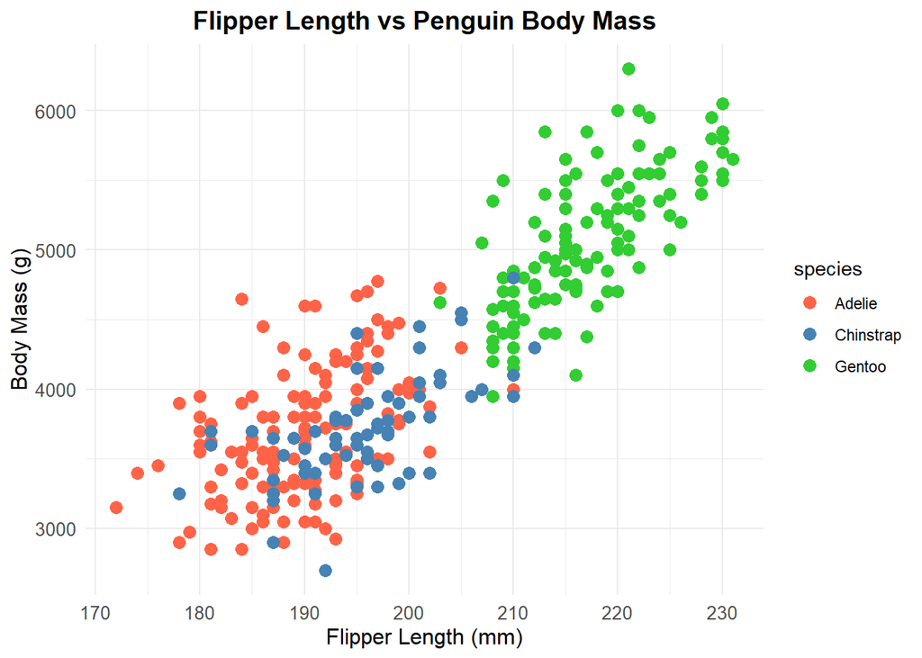

```r
## 5 - Mirror, mirror on the wall, who's the ugliest of them all?

## 5 - Mirror, mirror on the wall, who's the ugliest of them all?

# Load required libraries
library(ggplot2)
library(palmerpenguins)
# Basic plot with custom colors and styling
ggplot(penguins, aes(x = flipper_length_mm, y = body_mass_g, color = species)) +
geom_point(size = 3) +
labs(title = "Flipper Length vs Penguin Body Mass",
x = "Flipper Length (mm)",
y = "Body Mass (g)") +
scale_color_manual(values = c("Adelie" = "#FF6347", "Chinstrap" = "#4682B4", "Gentoo" = "#32CD32")) + theme_minimal() +
theme(plot.title = element_text(hjust = 0.5, size = 14, face = "bold"),
axis.title = element_text(size = 12),
axis.text = element_text(size = 10))
```

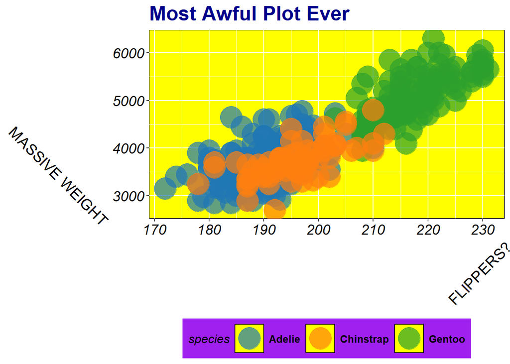

```r
# Load required libraries
library(ggplot2)
library(palmerpenguins)
# Plot with updated colors
ggplot(penguins, aes(x = flipper_length_mm, y = body_mass_g, color = species)) +
geom_point(size = 10, alpha = 0.7) +
labs(title = "Most Awful Plot Ever",
x = "FLIPPERS?",
y = "MASSIVE WEIGHT") +
theme(
panel.background = element_rect(fill = "yellow", color = "black"), # Subtle background
plot.title = element_text(size = 20, face = "bold", color = "darkblue"),
windowsFonts(Times = windowsFont("Times New Roman")),
axis.title.x = element_text(size = 15, angle = 45, hjust = 1),
axis.title.y = element_text(size = 15, angle = -45, hjust = 1),
axis.text = element_text(size = 14, color = "black", face = "italic"),
legend.position = "bottom",
legend.text = element_text(size = 10, face = "bold", color = "black"),
legend.title = element_text(size = 12, face = "italic")
) +
scale_color_manual(values = c("Adelie" = "#1f77b4", "Chinstrap" = "#ff7f0e", "Gentoo" = "#2ca02c")) +
theme(legend.background = element_rect(fill = "purple"))
```